# Lecture 12 · Pandas and Exploratory Data Analysis — Handout

COMP 521 · 30-minute introduction

## Pandas and exploratory data analysis

From labelled observations to inspectable evidence

Anna Rosen · San Diego State University

A Python library for labelled data

## What is Pandas?

### What it provides

- **DataFrame:** a table with row and column labels.
- **Series:** one labelled sequence, such as a column.
- Tools to read files, select records, handle missing values, and summarize data.

### Where it fits

NumPy computes with arrays. Pandas adds table labels and column types. Matplotlib draws the plots.

The usual import

```python
import pandas as pd
```

`pd` is an alias for the library, not a dataset.

Choose a representation for the task

## Compare the data containers

| Container | How you address data | What it organizes |
| --- | --- | --- |
| Python list | Positions | A sequence of objects |
| Python dictionary | Keys | Key–value associations |
| NumPy array | Positions in a shape | An array with one dtype |
| Pandas Series | Index labels or positions | One labelled sequence with one dtype |
| Pandas DataFrame | Row/column labels or positions | A table with one dtype per column |

A dictionary can supply a table’s columns. A DataFrame adds a shared row index and table operations; each column is a Series.

Synthetic teaching data

## A dictionary of columns becomes a DataFrame

Dictionary keys name the columns

```python
columns = {
    'sample': ['A', 'B', 'C', 'D', 'E'],
    'exposure_s': [1., 2., 2.5, np.nan, 4.],
    'signal': [2., 3., 3., 4., 18.],
    'quality': ['ok', 'ok', 'ok', 'ok', 'flagged']}
```

Give the table its row labels

```python
row_labels = ['r10', 'r11', 'r12',
              'r13', 'r14']
toy = pd.DataFrame(columns,
                   index=row_labels)
print(toy.to_string())
```

Each list supplies one column. Entries at the same position form one row.

These equal-length lists describe five synthetic exposures. Signal uses arbitrary units; exposure uses seconds.

What the representation preserves

## Inspect the records

```
    sample  exposure_s  signal  quality
r10      A         1.0     2.0       ok
r11      B         2.0     3.0       ok
r12      C         2.5     3.0       ok
r13      D         NaN     4.0       ok
r14      E         4.0    18.0  flagged
```

Sample D lacks an exposure. Sample E carries a flag. Keep both facts visible.

`toy.shape` is `(5, 4)`. Inspect `toy.index`, `toy.columns`, and `toy.dtypes`. Types do not supply units.

The brackets specify the result

## One column is a Series

A column and a subtable

```python
print(type(toy['signal']).__name__)
print(type(toy[['signal']]).__name__)
print(toy[['sample', 'signal']].to_string())
```

[output not shown]

| Expression | Result |
| --- | --- |
| `toy['signal']` | A labelled Series |
| `toy[['sample', 'signal']]` | A two-column DataFrame |

The inner list names the columns to keep.

Addressing a record

## Labels and positions are different

.loc uses labels; .iloc uses positions

```python
print(toy.loc['r10', 'signal'])
print(toy.iloc[0]['signal'])
row = toy.loc['r12', ['sample', 'signal']]
print(row.to_string())
```

```
2.0
2.0
sample      C
signal    3.0
```

The first row’s label is `r10`, while its position is `0`.

Keep quantities paired

## Columns support row-wise arithmetic

Signal divided by its own exposure

```python
rate = toy['signal'] / toy['exposure_s']
print(rate.to_string())
```

```
r10    2.0
r11    1.5
r12    1.2
r13    NaN
r14    4.5
```

Pandas matches row labels before dividing. These columns come from the same table. The result uses arbitrary signal units per second.

Preserve missingness

## Missing is a state, not a measured zero

`isna()` marks missing cells `True`. `.sum()` counts those marks down each column: `True` contributes 1; `False` contributes 0.

Find and count missing entries

```python
print(toy.isna().sum().to_string())
missing = toy['exposure_s'].isna()
fields = ['sample', 'exposure_s']
unknown = toy.loc[missing, fields]
print(unknown.to_string())
```

```
sample        0
exposure_s    1
signal        0
quality       0
    sample  exposure_s
r13      D         NaN
```

D’s rate is missing because its exposure is unknown. Replacing the exposure with zero would invent a value and change the calculation.

A boolean mask

## A comparison gives one decision per row

A named condition

```python
is_ok = toy['quality'].eq('ok')
print(is_ok.to_string())
```

```
r10     True
r11     True
r12     True
r13     True
r14    False
```

`.eq('ok')` compares each value with `'ok'`. The result is a boolean Series with the table’s row labels. `True` means keep that row for this rule.

Combine conditions with `&` (both), `|` (either), and `~` (reverse). Put comparisons in parentheses.

Selection preserves the rule

## Read `.loc[rows, columns]`

Select records and variables

```python
toy.loc[is_ok, ['sample', 'exposure_s', 'signal']]
```

- Before the comma: a row label, list of labels, or mask.
- After the comma: the columns to retain.
- Build the mask from the same table’s labelled columns.

In-class reasoning

## Explain the selection before running it

`is_ok` marks the rows with an “ok” quality flag. Compare these two selections:

Two row-selection rules

```python
toy.loc[is_ok]
toy.loc[is_ok & toy['exposure_s'].notna()]
```

Predict

Which row labels will each expression retain? Explain the difference.

Explain

The first keeps `r10`–`r13`. The second keeps `r10`–`r12`. Selection does not renumber labels or fill missing values.

Describe what is available

## Start EDA with counts and ranges

Descriptive summaries from the same table

```python
fields = ['exposure_s', 'signal']
summary = toy[fields].describe()
stats = ['count', 'mean', '50%',
         'min', 'max']
shown = summary.loc[stats].round(3)
print(shown.to_string())
```

```
       exposure_s  signal
count       4.000     5.0
mean        2.375     6.0
50%         2.250     3.0
min         1.000     2.0
max         4.000    18.0
```

`count` reports available values in each column. `50%` is the median. Different columns can summarize different numbers of observations.

Missing values change the available count

## The denominator matters

The four known exposures are 1, 2, 2.5, and 4 seconds.

Predict

Is their mean $9.5/4$ or $9.5/5$? What would the other denominator imply?

Explain

$$\bar t=\frac{1+2+2.5+4}{4}=2.375\ {\rm s}.$$

Dividing by five would effectively count the missing exposure as zero. The available-value mean does not establish that missingness is harmless.

EDA · one variable

## Plot a distribution, not just one number

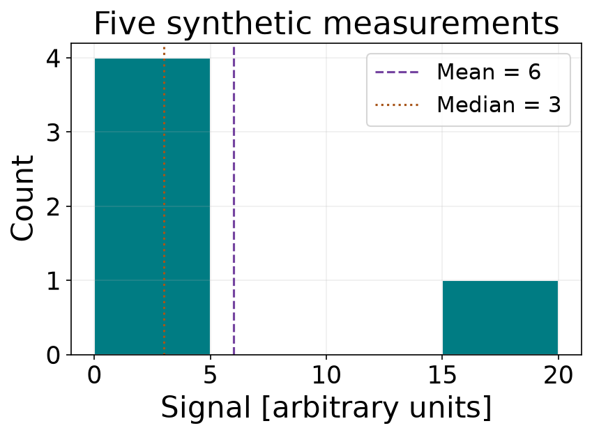

A bin is an interval of signal values. Its height counts stored values in that interval.

EDA · two variables

## A relationship requires paired records

`notna()` checks each cell. `.all(axis=1)` checks across columns within one row; both fields must be known.

Select rows with both variables

```python
xy = ['exposure_s', 'signal']
paired = toy[xy].notna().all(axis=1)
pairs = toy.loc[paired]
print(pairs.to_string())
```

```
    sample  exposure_s  signal  quality
r10      A         1.0     2.0       ok
r11      B         2.0     3.0       ok
r12      C         2.5     3.0       ok
r14      E         4.0    18.0  flagged
```

For this plot, retain rows with exposure **and** signal. Do not remove missing values separately from the two columns and then pair positions.

One published parameter set per planet

## The CSV has a source contract

The saved NASA **Planetary Systems (`ps`)** query retains one default published parameter set per planet, with names and source references.

Read your saved Project 4 file

```python
raw = pd.read_csv(
    'project4-nasa-exoplanets.csv',
    comment='#')
```

CSV is a text format with a header and comma-separated records. `read_csv` returns a DataFrame. Blank fields usually become missing values; check inferred types.

Save the CSV beside your own notebook. Keep the query and retrieval date.

Source before selection

## Inspect what was read

```
(437, 15)
     pl_name  pl_masse  pl_rade
TRAPPIST-1 h     0.326    0.755
TRAPPIST-1 d     0.388    0.788
    KOI-55 b     0.440    0.759
   L 98-59 b     0.460    0.837
```

`raw.shape` gives the dimensions. `raw.head(4)` previews the four rows shown here; `raw.head()` defaults to five. Inspect column types with `raw.dtypes`.

This snapshot has 437 rows and 15 columns. A later live query may differ.

Make selection reproducible

## Apply the rule and report the counts

Preserve raw; select planets

```python
keep = (finite & central & in_window
        & signed_errors
        & positive_lower)
planets = raw.loc[keep].copy()
print('Input:', len(raw))
print('Selected:', len(planets))
print('Excluded:', len(raw)-len(planets))
```

```
Input: 437
Selected: 371
Excluded: 66
```

The Project 4 brief supplies the comparison rule: finite central estimates, the mass window, signed uncertainty offsets, and positive lower endpoints.

This snapshot retains 371 of 437 rows. Failed conditions can overlap; their excluded counts should not be added independently.

EDA · selected radii

## Explore one variable

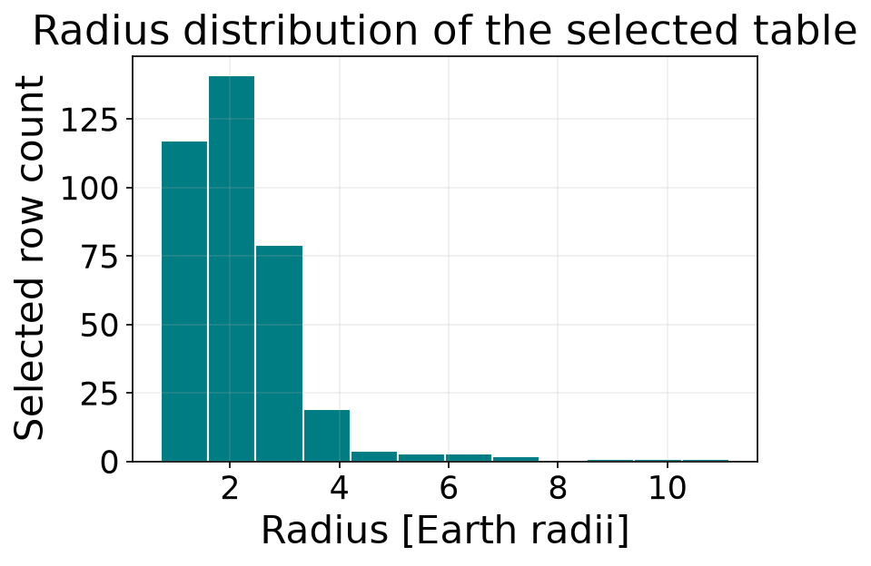

The shape depends on the selected table, available measurements, and binning.

An estimate includes precision information

## Read the relationship with its uncertainties

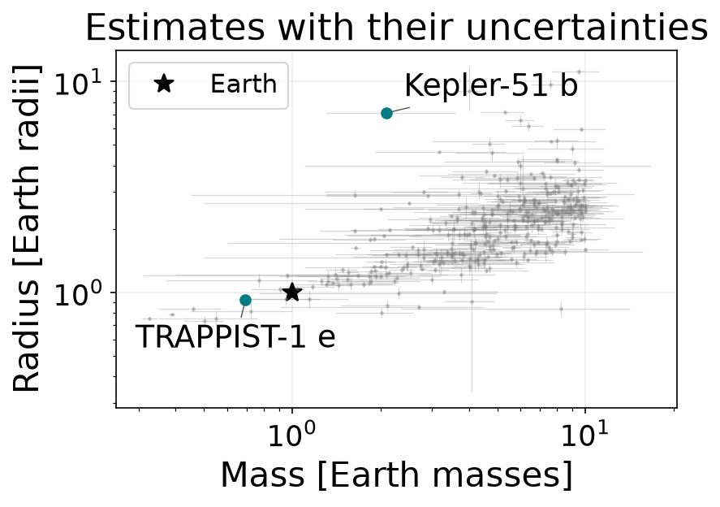

The supplied offsets follow their source studies; a common confidence level is not established here.

Bridge Pandas to NumPy and Matplotlib

## Reference recipe: preserve both uncertainties

Lower row, then upper row

```python
mass_errors = np.vstack((
    -planets['pl_masseerr2'].to_numpy(),
     planets['pl_masseerr1'].to_numpy()))
radius_errors = np.vstack((
    -planets['pl_radeerr2'].to_numpy(),
     planets['pl_radeerr1'].to_numpy()))
print(mass_errors.shape, radius_errors.shape)
```

[output not shown]

### Two rows, $N$ planets

$$\begin{pmatrix}
\text{lower lengths}\\
\text{upper lengths}
\end{pmatrix}$$

For Kepler-51 b, one column is $\begin{pmatrix}0.8\\1.5\end{pmatrix}$ Earth masses.

`.to_numpy()` extracts the values. `np.vstack` stacks them as rows.

One column per selected planet. Every array comes from the same selected rows in the same order.

Install, load, and explore

## Your turn: create your own notebook

In your course terminal

```bash
conda activate comp521
conda install -c conda-forge pandas
```

1. Create a blank Jupyter notebook beside the saved NASA CSV.
2. Import Pandas and load the CSV with `pd.read_csv`.
3. Inspect the table, choose columns, and try selections, summaries, and plots.
4. Discuss one result and one question with a neighbor.

[Download the CSV and read the setup instructions](https://astrobytes-edu.github.io/comp521/lecture-12-pandas/). This is class exploration, with no new submission.

Inspect the source

## References for your own notebook

- [Pandas table fundamentals](https://pandas.pydata.org/docs/user_guide/dsintro.html)
- [CSV reading](https://pandas.pydata.org/docs/reference/api/pandas.read_csv.html), [`.loc`](https://pandas.pydata.org/docs/reference/api/pandas.DataFrame.loc.html), and [descriptive summaries](https://pandas.pydata.org/docs/reference/api/pandas.DataFrame.describe.html)
- [Matplotlib error bars](https://matplotlib.org/stable/api/_as_gen/matplotlib.pyplot.errorbar.html)
- [NASA column definitions](https://exoplanetarchive.ipac.caltech.edu/docs/API_PS_columns.html)
- [Install Pandas](https://pandas.pydata.org/docs/getting_started/install.html) and [download the class CSV](https://astrobytes-edu.github.io/comp521/lecture-12-pandas/)
- [Project 4](https://astrobytes-edu.github.io/comp521/project-4/)